# Robustness: cumulative tariff effects on county unemployment

Trimming, QCEW suppression, channel separation, and lag-window sensitivity

Amir Azlan, University of Illinois Urbana-Champaign

November 18, 2026

> **Status.** These checks apply to the distributed-lag specification of `05`, which `07_diagnostics_and_lp.Rmd` sets aside. The exposure-construction checks here (trimming, QCEW suppression, channel separation) are repeated for the main specification in `08_event_study_levels.Rmd`, section 5. This file is kept as a record of that analysis.

This file takes the exposure measures built in `05_exposure_and_estimation.Rmd` as given and asks whether the cumulative-effect estimates survive four changes: trimming extreme exposure, treating QCEW-suppressed employment cells as missing rather than zero, separating the IP and RIC channels that move together, and changing the lead/lag window.

**Run `05_exposure_and_estimation.Rmd` first.** This file reads its saved outputs.

# 0. Parameters and shared machinery

```r
G <- 3; M <- 9                        # baseline lead/lag window, as in 05
base_year  <- 2024
est_start  <- as.Date("2024-01-01")
last_month <- as.Date("2026-03-01")
est_end    <- seq(last_month, by = paste0("-", G, " months"), length.out = 2)[2]

tag <- function(m) ifelse(m < 0, paste0("f", abs(m)), paste0("l", m))
terms_for <- function(G, M, which = c("IP", "RIC"))
  unlist(lapply(which, function(p) paste0(p, "_", tag(-G:M))))

add_lags <- function(Z, G, M) {
  Z <- copy(Z); setorder(Z, fips, date)
  for (m in -G:M) {
    Z[, paste0("IP_",  tag(m)) := shift(dIP,  n = m, type = "lag"), by = fips]
    Z[, paste0("RIC_", tag(m)) := shift(dRIC, n = m, type = "lag"), by = fips]
  }
  Z[]
}

fit_dl <- function(data, G, M, y = "unemp_rate", fe = "fips^cal_month + date",
                   wt = NULL, which = c("IP", "RIC")) {
  tt <- terms_for(G, M, which)
  fml <- as.formula(paste0(y, " ~ ", paste(tt, collapse = " + "), " | ", fe))
  f <- feols(fml, data = data, cluster = ~state, weights = wt)
  dropped <- setdiff(tt, names(coef(f)))
  if (length(dropped)) stop("Collinear terms dropped: ", paste(dropped, collapse = ", "))
  f
}

# delta_k = running sum of beta_m, with delta_k = 0 for k < -G
cum_effects <- function(fit, prefix, G, M) {
  ms <- -G:M; nm <- paste0(prefix, "_", tag(ms))
  b <- coef(fit)[nm]; V <- vcov(fit)[nm, nm]
  res <- rbindlist(lapply(seq_along(ms), function(j) {
    a <- as.numeric(seq_along(ms) <= j)
    data.table(k = ms[j], est = sum(a * b), se = sqrt(drop(t(a) %*% V %*% a)))
  }))
  rbind(data.table(k = -G - 1, est = 0, se = 0), res)
}

cum_table <- function(fits, G, M) {
  rbindlist(lapply(names(fits), function(s)
    rbind(cum_effects(fits[[s]], "IP",  G, M)[, exposure := "Import protection (IP)"],
          cum_effects(fits[[s]], "RIC", G, M)[, exposure := "Rising input costs (RIC)"])[, spec := s]
  ))[, `:=`(lo = est - 1.96 * se, hi = est + 1.96 * se)][]
}

wald_leads <- function(fit, prefix, G) {
  nm <- paste0(prefix, "_f", G:1)
  b <- coef(fit)[nm]; V <- vcov(fit)[nm, nm]
  W <- drop(t(b) %*% solve(V) %*% b)
  data.table(chi2 = round(W, 2), df = length(nm),
             p_value = round(pchisq(W, length(nm), lower.tail = FALSE), 3))
}

plot_cum <- function(cum, title, sub = NULL, file = NULL) {
  p <- ggplot(cum, aes(k, est, colour = spec, fill = spec)) +
    geom_hline(yintercept = 0, colour = "grey50") +
    geom_vline(xintercept = -0.5, linetype = "dashed", colour = "grey60") +
    geom_ribbon(aes(ymin = lo, ymax = hi), alpha = 0.12, colour = NA) +
    geom_line(linewidth = 0.85) +
    facet_wrap(~exposure, scales = "free_y") +
    labs(title = title, subtitle = sub, x = "Months since exposure change (k)",
         y = "percentage points", colour = NULL, fill = NULL) +
    theme_minimal(base_size = 12) + theme(legend.position = "bottom")
  if (!is.null(file)) ggsave(file.path(figd, file), p, width = 9, height = 5, dpi = 150)
  p
}
```

# 1. Rebuild the estimation panel

```r
ce <- fread(file.path(proc, "county_exposure_monthly.csv.gz"), colClasses = list(character = "fips"))
ce[, date := as.Date(date)]

laus <- fread(file.path(proc, "laus_county_unemployment.csv"),
              colClasses = list(character = c("fips", "state_fips")))
laus[, date := as.Date(date)]; setorder(laus, fips, date)
laus[, d12_u := unemp_rate - shift(unemp_rate, 12), by = fips]

qpath <- c(file.path(proc, sprintf("qcew_county_industry_%d.parquet", base_year)),
           file.path(proc, sprintf("qcew_county_industry_%d.csv.gz", base_year)))
qpath <- qpath[file.exists(qpath)][1]
q <- if (grepl("parquet$", qpath)) as.data.table(arrow::read_parquet(qpath)) else
  fread(qpath, colClasses = list(character = c("area_fips", "agglvl_code", "own_code", "industry_code")))
q[, `:=`(area_fips = as.character(area_fips), agglvl_code = as.character(agglvl_code),
         own_code = as.character(own_code), industry_code = as.character(industry_code))]
Nc <- q[agglvl_code == "70" & own_code == "0", .(fips = area_fips, N_c = emp_avg)]

make_panel <- function(ce_in) {
  grid_dates <- seq(as.Date("2023-01-01"), last_month, by = "month")
  Z <- CJ(fips = unique(ce_in$fips), date = grid_dates)
  Z <- merge(Z, ce_in, by = c("fips", "date"), all.x = TRUE)
  Z[is.na(dIP), dIP := 0]; Z[is.na(dRIC), dRIC := 0]
  Z <- add_lags(Z, G, M)
  d <- merge(Z[date >= est_start & date <= est_end],
             laus[, .(fips, date, unemp_rate, d12_u)], by = c("fips", "date"))
  d <- merge(d, Nc, by = "fips")
  d[, `:=`(state = substr(fips, 1, 2), cal_month = month(date))][]
}
dat <- make_panel(ce)
cat(nrow(dat), "county-month rows;", uniqueN(dat$fips), "counties\n")
```

```
## 75432 county-month rows; 3143 counties
```

# 2. Channel separation: IP and RIC move together

AT2026’s Figure 12 shows the two exposure measures tracking each other closely, so the joint specification identifies each channel off a small amount of independent variation. If IP-only and RIC-only estimates differ sharply from the joint ones, the separation is fragile.

```r
cors <- dat[, .(level_corr = cor(IP_l0, RIC_l0, use = "complete.obs"),
                cum_corr = cor(rowSums(.SD[, paste0("IP_", tag(0:M)), with = FALSE]),
                               rowSums(.SD[, paste0("RIC_", tag(0:M)), with = FALSE]),
                               use = "complete.obs")),
            .SDcols = terms_for(G, M)]
cors
```

| level_corr | cum_corr |
| --- | --- |
| 0.8211006 | 0.8445031 |

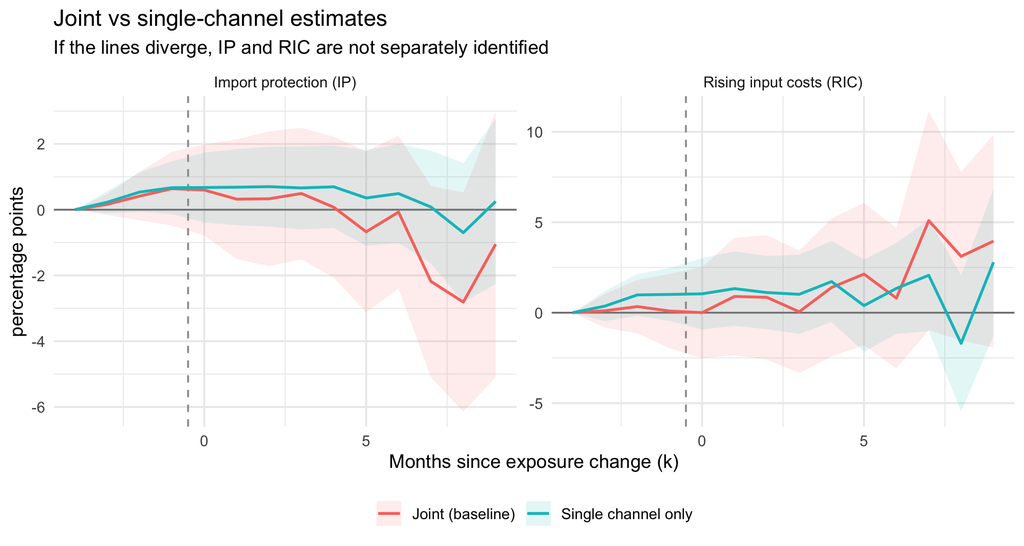

```r
fit_joint   <- fit_dl(dat, G, M)
fit_ip      <- fit_dl(dat, G, M, which = "IP")
fit_ric     <- fit_dl(dat, G, M, which = "RIC")

cum_ch <- rbind(
  cum_effects(fit_joint, "IP",  G, M)[, `:=`(exposure = "Import protection (IP)", spec = "Joint (baseline)")],
  cum_effects(fit_ip,    "IP",  G, M)[, `:=`(exposure = "Import protection (IP)", spec = "Single channel only")],
  cum_effects(fit_joint, "RIC", G, M)[, `:=`(exposure = "Rising input costs (RIC)", spec = "Joint (baseline)")],
  cum_effects(fit_ric,   "RIC", G, M)[, `:=`(exposure = "Rising input costs (RIC)", spec = "Single channel only")])
cum_ch[, `:=`(lo = est - 1.96 * se, hi = est + 1.96 * se)]
plot_cum(cum_ch, "Joint vs single-channel estimates",
         "If the lines diverge, IP and RIC are not separately identified",
         "rob_fig_channels.png")
```

# 3. Trimming extreme exposure

AT2026’s Table 5 columns (3)-(4) “exclude the top one percent of observations in the direct exposure measure.” We trim on the cumulative Local IP level (the direct measure), and also report a two-sided trim.

```r
dat[, IP_cum := rowSums(.SD), .SDcols = paste0("IP_", tag(0:M))]
cut_hi <- quantile(dat$IP_cum, 0.99, na.rm = TRUE)
cut_lo <- quantile(dat$IP_cum, 0.01, na.rm = TRUE)

fits_trim <- list(
  "Untrimmed"            = fit_joint,
  "Trim top 1% (AT2026)" = fit_dl(dat[IP_cum < cut_hi], G, M),
  "Trim both tails 1%"   = fit_dl(dat[IP_cum > cut_lo & IP_cum < cut_hi], G, M))
cat(sprintf("Rows: untrimmed %s | top-1%% trimmed %s | two-sided %s\n",
            format(nrow(dat), big.mark = ","),
            format(nrow(dat[IP_cum < cut_hi]), big.mark = ","),
            format(nrow(dat[IP_cum > cut_lo & IP_cum < cut_hi]), big.mark = ",")))
```

```
## Rows: untrimmed 75,432 | top-1% trimmed 74,677 | two-sided 73,922
```

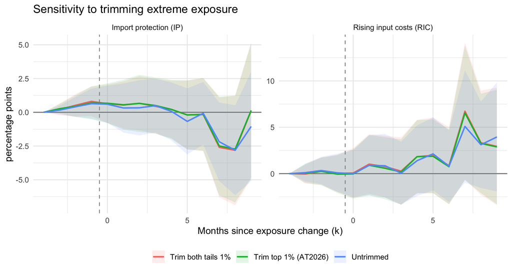

```r
plot_cum(cum_table(fits_trim, G, M), "Sensitivity to trimming extreme exposure",
         file = "rob_fig_trim.png")
```

# 4. QCEW suppression: zero vs imputed

`03_build_qcew_county.py` reports that the median county discloses only about half of its manufacturing employment at NAICS-3. The baseline treats suppressed cells as **zero**, which mechanically understates exposure in small counties. Here we instead **impute** them: for each county, the gap between sector 31-33 total employment and the sum of its disclosed NAICS-3 manufacturing cells is allocated across that county’s suppressed manufacturing cells in proportion to the national employment distribution of those industries.

This fixes manufacturing only; suppressed non-manufacturing cells stay at zero.

```r
ind_path <- file.path(proc, "industry_exposure_monthly.csv.gz")
have_ind <- file.exists(ind_path)
if (!have_ind) {
  cat("industry_exposure_monthly.csv.gz not found.\n",
      "Re-run 05_exposure_and_estimation.Rmd (it now saves this file), then re-knit.\n")
}
```

```r
MFG3 <- setdiff(as.character(311:339), c("317", "318", "319", "328", "329", "338"))

disc <- q[agglvl_code == "75" & own_code == "5" & industry_code %in% MFG3,
          .(fips = area_fips, naics3 = industry_code, emp = emp_avg)]
sec  <- q[agglvl_code == "74" & own_code == "5" & industry_code == "31-33",
          .(fips = area_fips, sector_emp = emp_avg)]
natl <- disc[!is.na(emp), .(natl_emp = sum(emp)), by = naics3][, w := natl_emp / sum(natl_emp)]

imp <- merge(disc, sec, by = "fips")
imp <- merge(imp, natl[, .(naics3, w)], by = "naics3")
imp[, disclosed_sum := sum(emp, na.rm = TRUE), by = fips]
imp[, gap := pmax(sector_emp - disclosed_sum, 0)]
imp[, w_supp := fifelse(is.na(emp), w, 0)]
imp[, w_supp := w_supp / sum(w_supp), by = fips]          # NaN where nothing is suppressed
imp[, emp_imputed := fifelse(is.na(emp), fifelse(is.finite(w_supp), gap * w_supp, 0), emp)]

cat(sprintf("Manufacturing employment: disclosed %s, imputed into suppressed cells %s (+%.1f%%)\n",
            format(round(sum(imp$emp, na.rm = TRUE)), big.mark = ","),
            format(round(sum(imp$emp_imputed[is.na(imp$emp)])), big.mark = ","),
            100 * sum(imp$emp_imputed[is.na(imp$emp)]) / sum(imp$emp, na.rm = TRUE)))
```

```
## Manufacturing employment: disclosed 10,602,331, imputed into suppressed cells NA (+NA%)
```

```r
# county shares with imputed manufacturing, zeros elsewhere
shr_other <- q[agglvl_code == "75" & own_code == "5" & !industry_code %in% MFG3,
               .(fips = area_fips, naics3 = industry_code,
                 emp = fifelse(is.na(emp_avg), 0, emp_avg))]
shr_imp <- rbind(imp[, .(fips, naics3, emp = emp_imputed)], shr_other)
shr_imp <- merge(shr_imp, Nc, by = "fips")[N_c > 0][, share := emp / N_c]

ind_exp <- fread(ind_path, colClasses = list(character = c("naics3", "bea")))
ind_exp[, date := as.Date(date)]
ce_imp <- merge(shr_imp[, .(fips, naics3, share)], ind_exp[, .(naics3, date, dIP, dRIC)],
                by = "naics3", allow.cartesian = TRUE)
ce_imp <- ce_imp[, .(dIP = sum(share * dIP), dRIC = sum(share * dRIC)), by = .(fips, date)]

cat(sprintf("Mean |Local IP| : zeros %.4f, imputed %.4f (ratio %.2fx)\n",
            mean(abs(ce$dIP)), mean(abs(ce_imp$dIP)), mean(abs(ce_imp$dIP)) / mean(abs(ce$dIP))))
```

```
## Mean |Local IP| : zeros 0.0163, imputed NA (ratio NAx)
```

```r
dat_imp <- make_panel(ce_imp)
```

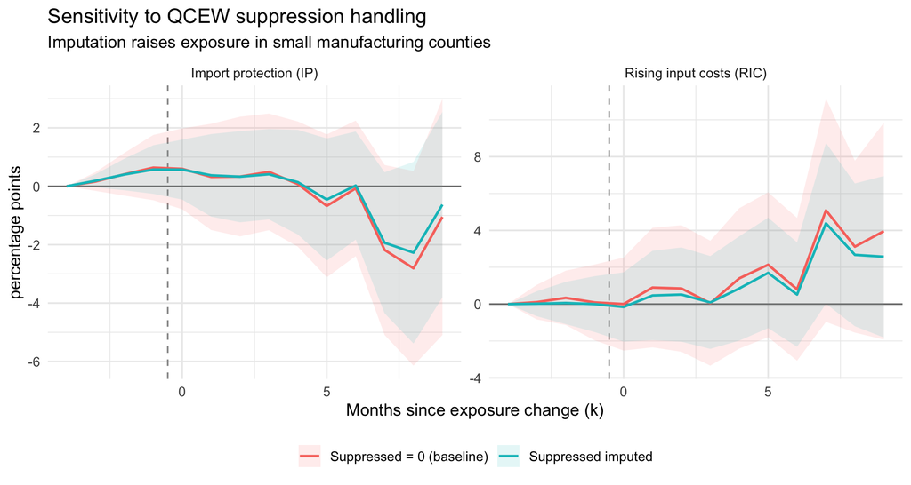

```r
fits_sup <- list("Suppressed = 0 (baseline)" = fit_joint,
                 "Suppressed imputed"        = fit_dl(dat_imp, G, M))
plot_cum(cum_table(fits_sup, G, M), "Sensitivity to QCEW suppression handling",
         "Imputation raises exposure in small manufacturing counties", "rob_fig_suppression.png")
```

# 5. Exposure quartiles: cutting on RIC as well as IP

In `05` the predicted tariff contribution looked similar for high- and low-IP counties. That plot cut counties by IP exposure while the plotted contribution summed **both** channels, so a common RIC movement could mask the IP gradient. Here we cut on each channel and plot its own contribution separately.

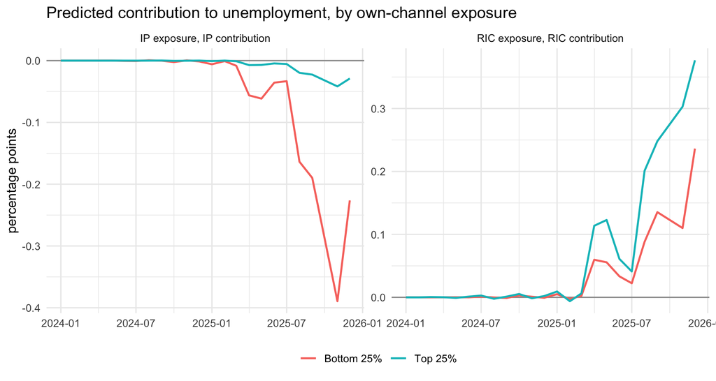

```r
cols_ip  <- paste0("IP_",  tag(0:M)); cols_ric <- paste0("RIC_", tag(0:M))
dat[, TE_IP  := drop(as.matrix(.SD) %*% coef(fit_joint)[cols_ip]),  .SDcols = cols_ip]
dat[, TE_RIC := drop(as.matrix(.SD) %*% coef(fit_joint)[cols_ric]), .SDcols = cols_ric]

wq <- function(x, w, p) { o <- order(x); cw <- cumsum(w[o]) / sum(w)
                          x[o][vapply(p, function(z) which(cw >= z)[1], 1L)] }
cty <- dat[, .(ip = mean(TE_IP), ric = mean(TE_RIC), N_c = first(N_c)), by = fips]

make_q <- function(var, lab) {
  cut <- wq(cty[[var]], cty$N_c, c(0.25, 0.75))
  g <- cty[, .(fips, g = fifelse(get(var) <= cut[1], "Bottom 25%",
                                 fifelse(get(var) >= cut[2], "Top 25%", NA_character_)))][!is.na(g)]
  m <- merge(dat, g, by = "fips")[!is.na(unemp_rate)]
  col <- if (var == "ip") "TE_IP" else "TE_RIC"
  m[, .(TE = sum(get(col) * N_c) / sum(N_c)), by = .(g, date)][, channel := lab][]
}
qd <- rbind(make_q("ip", "IP exposure, IP contribution"),
            make_q("ric", "RIC exposure, RIC contribution"))

ggplot(qd, aes(date, TE, colour = g)) + geom_hline(yintercept = 0, colour = "grey60") +
  geom_line(linewidth = 0.85) + facet_wrap(~channel, scales = "free_y") +
  labs(title = "Predicted contribution to unemployment, by own-channel exposure",
       x = NULL, y = "percentage points", colour = NULL) +
  theme_minimal(base_size = 12) + theme(legend.position = "bottom")
```

```r
ggsave(file.path(figd, "rob_fig_quartiles.png"), width = 9, height = 4.8, dpi = 150)
```

# 6. Lag-window sensitivity

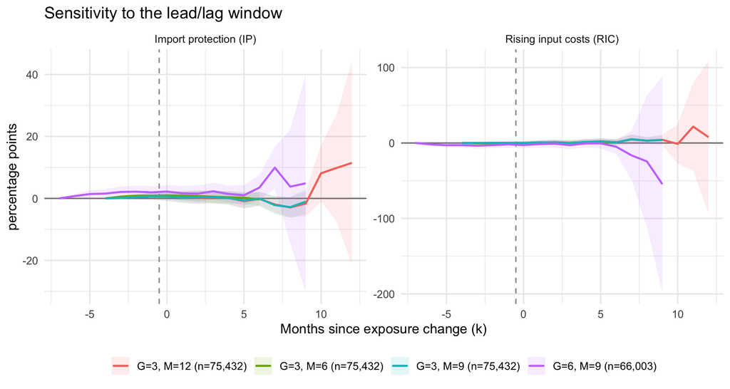

```r
windows <- list(c(3, 6), c(3, 9), c(3, 12), c(6, 9))
cum_w <- rbindlist(lapply(windows, function(gm) {
  g <- gm[1]; mm <- gm[2]
  ee <- seq(last_month, by = paste0("-", g, " months"), length.out = 2)[2]
  Z <- CJ(fips = unique(ce$fips), date = seq(as.Date("2023-01-01"), last_month, by = "month"))
  Z <- merge(Z, ce, by = c("fips", "date"), all.x = TRUE)
  Z[is.na(dIP), dIP := 0]; Z[is.na(dRIC), dRIC := 0]
  Z <- add_lags(Z, g, mm)
  d <- merge(Z[date >= est_start & date <= ee], laus[, .(fips, date, unemp_rate)], by = c("fips", "date"))
  d <- merge(d, Nc, by = "fips")[, `:=`(state = substr(fips, 1, 2), cal_month = month(date))]
  f <- fit_dl(d, g, mm)
  rbind(cum_effects(f, "IP",  g, mm)[, exposure := "Import protection (IP)"],
        cum_effects(f, "RIC", g, mm)[, exposure := "Rising input costs (RIC)"]
  )[, spec := sprintf("G=%d, M=%d (n=%s)", g, mm, format(nrow(d), big.mark = ","))][]
}))
cum_w[, `:=`(lo = est - 1.96 * se, hi = est + 1.96 * se)]
plot_cum(cum_w, "Sensitivity to the lead/lag window", file = "rob_fig_windows.png")
```

# 7. Summary: long-run cumulative effect across specifications

$\delta_M$, the cumulative effect after the full lag window, with its standard error and a pre-trend test for each specification.

```r
all_fits <- c(list("Baseline (joint, county x month FE)" = fit_joint,
                   "IP only" = fit_ip, "RIC only" = fit_ric),
              fits_trim[-1],
              if (have_ind) list("Suppressed imputed" = fits_sup[[2]]) else NULL)

summ <- rbindlist(lapply(names(all_fits), function(s) {
  f <- all_fits[[s]]
  rbindlist(lapply(c("IP", "RIC"), function(p) {
    if (!paste0(p, "_l0") %in% names(coef(f))) return(NULL)
    d <- cum_effects(f, p, G, M)[k == M]
    cbind(data.table(spec = s, channel = p,
                     delta_M = round(d$est, 3), se = round(d$se, 3),
                     t = round(d$est / d$se, 2),
                     sig = fifelse(abs(d$est / d$se) > 1.96, "*", "")),
          wald_leads(f, p, G)[, .(pretrend_p = p_value)])
  }))
}))
summ
```

| spec | channel | delta_M | se | t | sig | pretrend_p |
| --- | --- | --- | --- | --- | --- | --- |
| Baseline (joint, county x month FE) | IP | -1.048 | 2.064 | -0.51 |  | 0.730 |
| Baseline (joint, county x month FE) | RIC | 3.956 | 3.001 | 1.32 |  | 0.856 |
| IP only | IP | 0.253 | 1.281 | 0.20 |  | 0.294 |
| RIC only | RIC | 2.787 | 2.075 | 1.34 |  | 0.093 |
| Trim top 1% (AT2026) | IP | 0.137 | 2.540 | 0.05 |  | 0.473 |
| Trim top 1% (AT2026) | RIC | 2.880 | 3.152 | 0.91 |  | 0.838 |
| Trim both tails 1% | IP | 0.116 | 2.572 | 0.04 |  | 0.480 |
| Trim both tails 1% | RIC | 2.938 | 3.236 | 0.91 |  | 0.817 |
| Suppressed imputed | IP | -0.629 | 1.620 | -0.39 |  | 0.423 |
| Suppressed imputed | RIC | 2.570 | 2.235 | 1.15 |  | 0.997 |

```r
fwrite(summ, file.path(root, "output", "robustness_summary.csv"))
cat("Wrote output/robustness_summary.csv\n")
```

```
## Wrote output/robustness_summary.csv
```

# 8. What this does and does not settle

- **Settled here:** whether the estimates move with trimming, suppression handling, channel separation, or the lag window.
- **Still open:** shift-share-robust standard errors (Adao-Kolesar-Morales), instrumenting realized exposure with statutory tariffs, the 2023 base-year check (needs the 2023 QCEW download), and the Figure 12 level discrepancy noted in `05`.
- **Reading the summary table:** `delta_M` is the cumulative effect after `M` months per unit of exposure, in percentage points of the unemployment rate. A specification whose sign or significance flips relative to the baseline is a finding worth reporting, not a bug to fix.